# K-Means clustering: How Many K’s?

Mitch Sanders

3/16/2017

# Get Ready - Build Some Random X and Y Data to Cluster

- Clear the memory - (just a good habit… clear out any cache values lying around)
- Set a seed for reproducibility (any number will do)
- Generate a random list of numbers centered around zero with a standard deviation of one

```r
rm(list=ls()); # clears all memory objects
set.seed(2) # set seed
x <- rnorm(100) # vector of random normalized data
```

Let’s visualize the data quickly to see if we got what we wanted

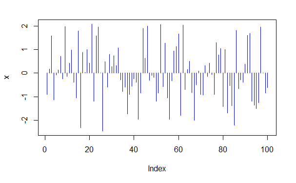

```r
plot(x, type="h", col="blue")
```

## Let’s Make a 2 Column Matrix and Offset Some

*Split data*  
Let’s split that our existing x data into 2 columns so we have have X’s and Y’s. We’ll use these for a 2-dimensional scattor plot which we’ll then try to find natural groups or clusterings based on the distances they are from each other.

*A little more data manipulation - Offsetting*  
1. Offsetting some of the data in the matrix  
2. This is to create a varied spread on the data point. Adjusting the +3 and -4 experimentally will show variations on the x and y plotting

```r
x <- matrix(x, ncol=2) # create a matrix from the vector with two columns
colnames(x) <- c("x","Y") # giving names to the two columns
x[1:25,1] <- x[1:25,1] +3 #offsetting
x[1:25,2] <- x[1:25,2] -4 #offsetting
```

## Looking at the Data

Let’s check and see what our matrix numbers look like. This matrix is in the “x” object. We’ll just look at the first 10 rows, but want to see both columns 1 and 2 for sure.

```r
x[1:10, 1:2] # looking a just the top 10 rows, both columns
```

```
             x         Y
 [1,] 2.103085 -4.838287
 [2,] 3.184849 -1.933699
 [3,] 4.587845 -4.562247
 [4,] 1.869624 -2.724284
 [5,] 2.919748 -5.047573
 [6,] 3.132420 -5.965878
 [7,] 3.707955 -4.322971
 [8,] 2.760302 -3.064137
 [9,] 4.984474 -2.860770
[10,] 2.861213 -2.328381
```

## Plot the Data - Scatterplot, 2 variables

Set seed again, and plot the existing data on X axis and Y axis

Also setting up some simple plotting indenting

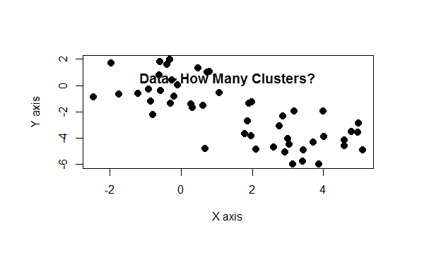

```r
set.seed(4)
par(oma=c(2,2,2,2)) # plot spacing parameters set globally for now
plot(x, xlab="X axis", ylab="Y axis", pch=20, cex=2)
title("Data - How Many Clusters?", line = -2)
```

:

# GO! We’re Ready to Cluster

## Running K-Means Algorithm

- Set a starting seed (remember - we want this reproducible!)
- Pass our matrix object into the K-means function as a parameter “kmeans(x)”
- Set kmeans parameter cluster number - Pick a number based on best guess or subject matter experts knowledge - (we’ll start with 5)
- Set kmeans parameter number of random starts - (This algorithm randomly places starting points for each cluster. This is the number of times it tries this to get to convergence. We’ll try 20)
- Pass results of this whole process into another variable

```r
set.seed(4)
km.output <- kmeans(x,5,nstart=20);
```

## Plot the x matrix object again and color code it by the k-means clusters

We’ll also set some other plot parameters like character type, size, give it a title and space the title one line.

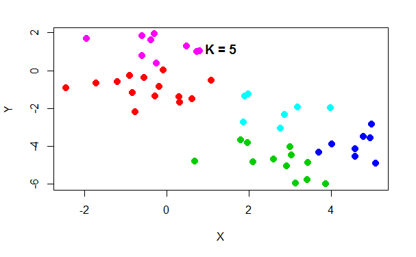

```r
plot(x, col=(km.output$cluster+1), xlab="X", ylab="Y", pch=20, cex=2)
title("K = 5", line = -2)
```

## Now we’ve ran a machine learning algorithm to find 5 clusters in a 2 dimensional dataset

- Is 5 clusters the best fit?
- Let’s check some other clustering numbers and visualize what we get.
- What would 4 clusters look like?
- Same code, change the k parameter.

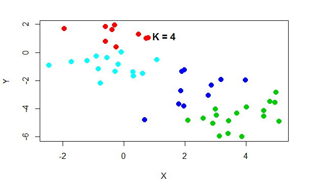

```r
set.seed(4)
km.output <- kmeans(x,4,nstart=20);
plot(x, col=(km.output$cluster+1), xlab="X", ylab="Y", pch=20, cex=2)
title("K = 4", line = -2)
```

hmmmm….. don’t think I would have seen that clustering of 4 either with just my own eyes. Glad to let the machine learn and do it for me.  
let’s try 3 clusters…

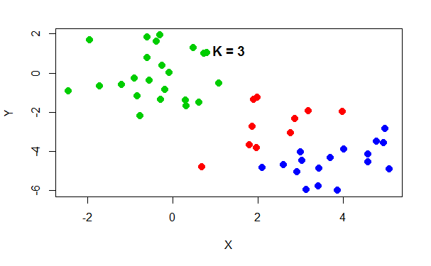

```r
set.seed(4)
km.output <- kmeans(x,3,nstart=20);
plot(x, col=(km.output$cluster+1), xlab="X", ylab="Y", pch=20, cex=2)
title("K = 3", line = -2)
```

Okay…. I can see that being natural clusters. How about just 2 clusters?

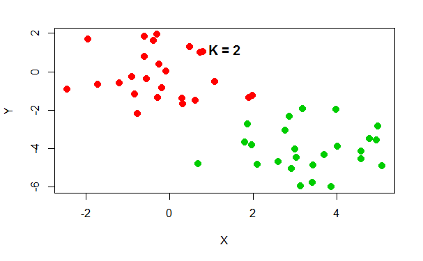

```r
set.seed(4)
km.output <- kmeans(x,2,nstart=20);
plot(x, col=(km.output$cluster+1), xlab="X", ylab="Y", pch=20, cex=2)
title("K = 2", line = -2)
```

Okay, now that’s how I would have partioned this data. Maybe a few outliers I might have placed in the other cluster, but this seems pretty natural. But does it really tell me anything?

Ah… that’s the question isn’t it?

# Next… Digging Deeper

- Finding how to best pick the “k” value.
- After that, bigger and better K type partiioning
- clustering: K-Means++, K-Medoid, and more.
- And what about this Euclidean distancing measurement. Why not a Manhattan measurement?
- And hows this work with more than 2 dimensions? 3? 4? 100? 1000? Can we visualize it?
- What are other options for Unsupervised Machine Learning clustering?

# Documentation

- “kmeans” in R is a program wrapped into a single function built into the R **stats** package.
- If you want to **see** the actual program, type in just “kmeans” in the R command line and hit enter. You can do this with lots of R fucntions.
- For docmentation and simple use of kmeans in R, type in “?kmeans” and enter. This is standard **help** for all R documentation

: